# Peirce y la lógica

Gnoseología

Gavriloff, Ivan Vladimir

FFyL 2026

1. Introducción
2. Aportes
3. Anticipos
4. Legado

> Entiendo que mi padre ha sugerido mi nombre para el puesto de catedrático de física (o profesor titular de física). Pero suponiendo que se decidiera llamarme a la Universidad (una llamada que me resultaría muy agradable), creo que sería más ventajoso utilizarme, primero, para cubrir la necesidad precisa del departamento de física, y segundo, para utilizar mis estudios de lógica.

> […]

> Pero en cuanto a mí, soy un lógico. Los datos para las generalizaciones de la lógica son los métodos especiales de las diferentes ciencias. Para penetrar estos métodos, el lógico tiene que estudiar varias ciencias con bastante profundidad.

Peirce a Gilman (JHU), 13-01-1878

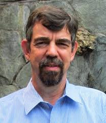

## Arnold Oostra

Matemático colombiano

Universidad del Tolima

Referencias: Oostra (2004, 2012a, 2012b)

# Cronología

1879 – 1885

Universidad de Johns Hopkins

1897 – 1905

60 años de edad

[figure not shown]

Boole – De Morgan – Peirce – Schröder – Löwenheim – Skolem – Tarski

# Mejoras a la lógica de Boole

## 1880 – 1885

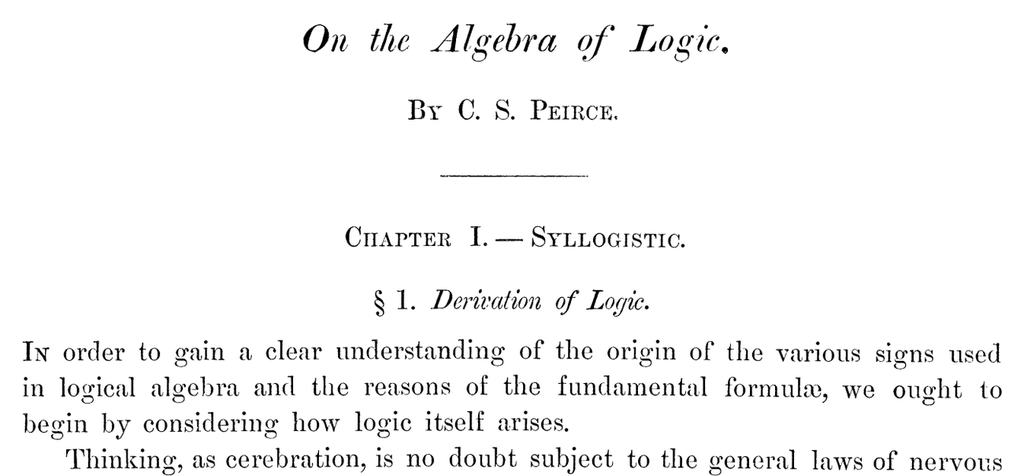

## 1880 – 1885

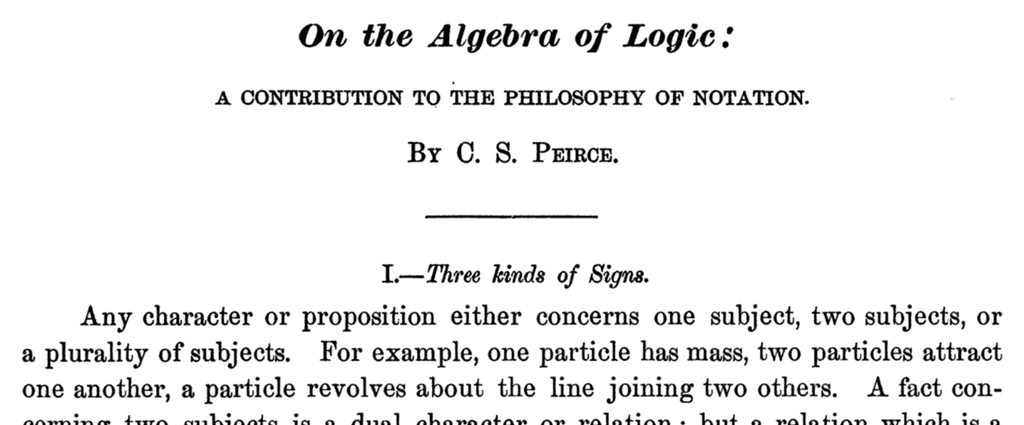

## Resultados

### Lógica de primer orden

Completa y consistente

### Ley de Peirce

[(*p* → *q*) → *p*] → *p*

### Lógica de relativos

1879 – 1884

### Cuantificadores (1885)

Σ<sub>*i*</sub> *x*<sub>*i*</sub>, Π<sub>*i*</sub> *x*<sub>*i*</sub>

## Ley de Peirce

# Anticipos

## Notación completa para los 16 conectivos de la lógica proposicional

1902

[figure not shown]

signo

[figure not shown]

forma de caja

Tabla 1. Notación de Peirce para los conectivos binarios (1902).

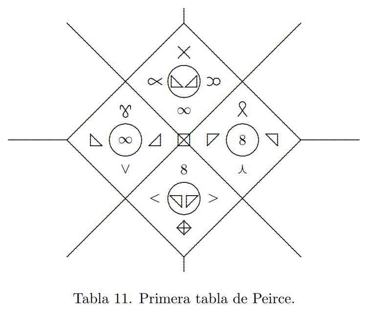

# Legado

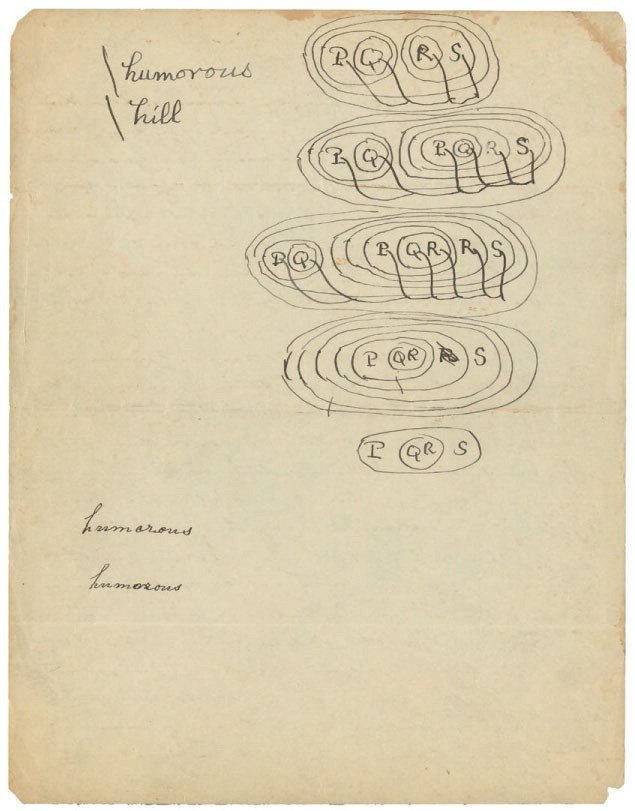

## Gráficos existenciales

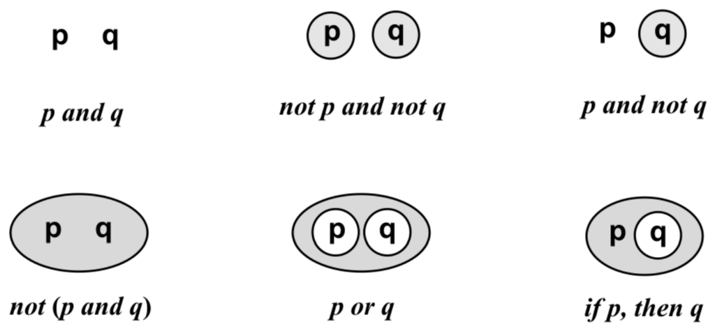

Gráficos existenciales: lógica proposicional

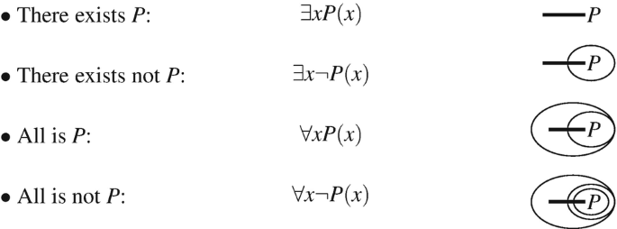

Gráficos existenciales: cuantificadores

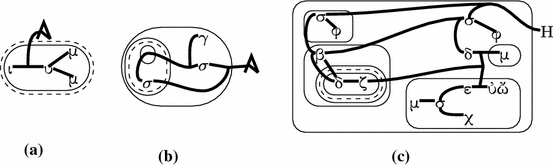

Gráficos existenciales: ejemplos con relaciones

[figure not shown]